# Language Differences in Autobiographical Narratives from Older Adults

Kimberly Halberstadter

May 2026

This project is a simulated pipeline to be used for a future project with  
qualitative interview data collected from a sample of community-dwelling  
older adults. These adults will have completed a quantitative measure of  
“purpose in life” along with other demographic surveys. Interviews will include  
questions on life outlook. For the sake of this class project and the development  
of a working pipeline, simulated “autobiographical narratives” were generated  
using ChatGPT, and variables for age and purpose were randomly generated using  
a value range consistent with the anticipated data. The analyses do not refllect  
“real” results and thus cannot be interpreted with seriousness; however, they  
demonstrate a working pipeline for future analyses.

# 1. Load Narrative Data

For the purpose of this project, I am using a simulated data set derived by Chat GPT using several refined parameters.  
The file contains 50 participants, each with a random age between 60-99 and a unique autobiographical narrative.

```r
narrative <- read.csv("data/diverse_structured_narratives.csv", fileEncoding = "UTF-8")
head(narrative)
```

| age | narrative |
| --- | --- |
| 62 | Let me try to answer your question, though I’m not sure I ever fully understood my own life. There’s a warmth when I look back, even at the difficult parts. I found myself shaped more by circumstance … |
| 63 | Sit with me a moment, and I’ll tell you what I can remember. Some parts are hard to revisit, but they are part of the truth. I found myself shaped more by circumstance than intention at times. Sometim… |
| 74 | You asked me to tell you my life story, and I suppose there’s no simple way to do that. Some parts are hard to revisit, but they are part of the truth. I moved through different phases—some driven by … |
| 93 | Let me try to answer your question, though I’m not sure I ever fully understood my own life. Looking back, it feels like a series of events more than a clear arc. I moved through different phases—some… |
| 78 | Sit with me a moment, and I’ll tell you what I can remember. Looking back, it feels like a series of events more than a clear arc. People came and went, and each left something behind in me. I didn’t … |
| 74 | I’ve lived long enough to know that stories rarely begin where we think they do. There’s a warmth when I look back, even at the difficult parts. I moved through different phases—some driven by ambitio… |

```r
# Add ID variable
narrative <- narrative %>%
    mutate(ID = row_number())
```

# 2. Load Lookup Database & Pull Selected Variables

For this project, I will be looking at valence, boredom, and excitement.

```r
load("utils/lookup_Jul25.rda")
lookup_subset <- lookup_Jul25 %>%
    dplyr::select(word, emo_boredom, emo_excitement, emo_valence_b24)
```

# 3. Clean Narrative Data

For these analyses, I will clean each narrative sample to remove non-letter characters,  
spacing issues, and stop words. I will NOT lemmatize the text.

## Add “Purpose” variable

This randomly generated varialbe will simulate my purpose in life predictor score.

```r
set.seed(123)
narrative$purpose <- runif(n = nrow(narrative), min = 1, max = 6)
```

## Load cleaning genie

```r
kimmy_genie <- function(dat, wordcol,
                        which_stops = c("none", "Temple", "MIT", "SMART"),
                        lemmatize = FALSE) {

library(dplyr)
library(tidyr)
library(stringr)
library(stringi)
library(textstem)

# Initial checks to make sure file loaded is properly formatted

## Check that input is a data frame
  if(!is.data.frame(dat)) {
    stop("dat must be a data frame for this function to work.")
  }

## Check that wordcol exists and can be used
  if(!wordcol %in% names(dat)) {
    stop(
      paste0(
        "wordcol must be a column name in dat for this function to work.",
        "Column '", wordcol, "' was not found."
      )
    )
  }

# Load replacement lists

load(file = "utils/replacements_25.rda") # Loads the file with contractions & replacements
  # Normalize quotations in replacements file
  replacements_25 <- replacements_25 %>%
    dplyr::mutate(
      word = stringr::str_replace_all(word, "’", "'")) %>%
    dplyr::mutate(
      word = stringr::str_replace_all(word, "‘", "'"))

load(file = "utils/Temple_stops25.rda") # Loads the file with contractions & replacements
load(file = "utils/SMART_stops.rda") # Loads the file with contractions & replacements
load(file = "utils/MIT_stops.rda") # Loads the file with contractions & replacements

# Create new data frame for cleaning, add variables to track progress

dat_clean <- dat %>% dplyr::mutate(id_row_orig = factor(seq_len(nrow(dat))), # create variable printing original text row
                                   text_orig = stringi::stri_enc_toutf8(as.character(.[[wordcol]]),
                                                                              validate = TRUE)) # creates new column with original text in UTF-8

# Cleaning of original text before word split

## All lowercase
dat_clean <- dat_clean %>%
  dplyr::mutate(
    text_orig = tolower(text_orig)
  )

## Normalize apostrophes

#dat_clean <- dat_clean %>%
  #dplyr::mutate(
    #text_orig = stringr::str_replace_all(text_orig, "’", "'")) %>%
  #dplyr::mutate(
    #text_orig = stringr::str_replace_all(text_orig, "‘", "'"))

dat_clean <- dat_clean %>%
  dplyr::mutate(
    text_orig = ifelse(
      is.na(text_orig), NA_character_, stringi::stri_replace_all_regex(
        text_orig,
        "[\u2018\u2019\u02BC\u201B\uFF07\u0092\u0091\u0060\u00B4\u2032\u2035]",
        "'"
      )
    )
  )

# Split original text by word

dat_clean <- dat_clean %>%
  dplyr::mutate(
    text_orig = str_split(text_orig, "\\s+")) %>%
  unnest(text_orig)

# Remove original wordcol

dat_clean <- dat_clean %>%
  dplyr::select(-all_of(wordcol))

# Add new column for bulk cleaning

dat_clean <- dat_clean %>%
  dplyr::mutate(
    text_clean = text_orig
  )

# MAIN CLEANING by word within "text_clean"

## Expand contractions
replace_contractions <- function(text_clean, replacement_df) {
  # Replace each bad word with its corresponding good word
  for(i in seq_len(nrow(replacement_df))) {
    text_clean <- gsub(
      pattern = replacement_df$word[i],
      replacement = replacement_df$replacement[i],
      x = text_clean,
      ignore.case = TRUE
    )
  }
  return(text_clean)
}

  # Run replace_contractions on dat_clean
  dat_clean$text_clean <- replace_contractions(dat_clean$text_clean, replacement_df = replacements_25)
  #test_clean <- replace_contractions("didn't", replacement_df = replacements_25)

  # Re-split text_clean by word after expanding contractions
  dat_clean <- dat_clean %>%
  dplyr::mutate(
    text_clean = str_split(text_clean, "\\s+")) %>%
  unnest(text_clean)

## Split hyphenated words

  # Split hyphenated words
  dat_clean$text_clean <- gsub("-", " ", dat_clean$text_clean) # replaces hyphen with space to make any hypheanted word 2 words

  # Re-split text_clean by word after splitting hyphenated words
  dat_clean <- dat_clean %>%
  dplyr::mutate(
    text_clean = str_split(text_clean, "\\s+")) %>%
  unnest(text_clean)

## Omit singletons, numerals, punctuation
  dat_clean$text_clean <- gsub("\\b[a-zA-Z]\\b{1}", " ", dat_clean$text_clean) #omits singletons including Aa and Ii
  dat_clean$text_clean <- gsub("[^A-Za-z ]","",dat_clean$text_clean) #remove numerals and punctuation

## Remove excess white space & empty strings
  dat_clean$text_clean <- stripWhitespace(dat_clean$text_clean) #removes excess white space
  dat_clean$text_clean[dat_clean$text_clean == ""] <- NA #replaces empty strings with NA

## Replace any "empty" cells with NA
  dat_clean$text_clean[dat_clean$text_clean == ""] <- NA
  dat_clean$text_clean[dat_clean$text_clean == " "] <- NA

## Remove single stop words (not multi-word stop phrases) - IF DESIRED

  # Remove stops function
  remove_stops <- function(text_clean, stops_df) {
    stop_words <- stops_df$word[!grepl(" ",stops_df$word)]
    text_clean[text_clean %in% stop_words] <- NA

  return(text_clean)
  }

  # Apply for various stop word files
  which_stops <- match.arg(which_stops)

  # Creates list of possible stop word files or NULL
  stops_df <- switch(which_stops,
                     "Temple" = Temple_stops25,
                     "MIT" = MIT_stops,
                     "SMART" = SMART_stops,
                     "none" = NULL)

  # Runs function using selected stop word file
  if(!is.null(stops_df)) {
    dat_clean$text_clean <- remove_stops(
      dat_clean$text_clean,
      stops_df = stops_df
    )
  }

## Lemmatize - IF DESIRED

  # Lemmatize
  if(lemmatize) {dat_clean$text_clean <- lemmatize_strings(dat_clean$text_clean)}

  # Check to make sure lemmatization is working
  cat("=== Lemmatization Flags ===\n")
  cat("Lemmatization active:", lemmatize, "\n")
  cat("===========================\n")

return(dat_clean)

}
```

## Run cleaning genie (without lemmatization)

```r
narrative_cleaned <- kimmy_genie(narrative, wordcol = "narrative", which_stops = "Temple",
    lemmatize = FALSE)
```

```
## === Lemmatization Flags ===
## Lemmatization active: FALSE
## ===========================
```

```r
head(narrative_cleaned)
```

| age | ID | purpose | id_row_orig | text_orig | text_clean |
| --- | --- | --- | --- | --- | --- |
| 62 | 1 | 2.44 | 1 | let | let |
| 62 | 1 | 2.44 | 1 | me | NA |
| 62 | 1 | 2.44 | 1 | try | try |
| 62 | 1 | 2.44 | 1 | to | NA |
| 62 | 1 | 2.44 | 1 | answer | answer |
| 62 | 1 | 2.44 | 1 | your | NA |

# 4. Prepare Merged Data Set

## Join lookup variables

Now I will join the lookup values to my cleaned data set.

```r
# Change 'text_clean' variable to 'word'
narrative_cleaned <- narrative_cleaned %>%
    rename(word = text_clean)

narrative_joined <- narrative_cleaned %>%
    left_join(lookup_subset, by = "word")
head(narrative_joined)
```

| age | ID | purpose | id_row_orig | text_orig | word | emo_boredom | emo_excitement | emo_valence_b24 |
| --- | --- | --- | --- | --- | --- | --- | --- | --- |
| 62 | 1 | 2.44 | 1 | let | let | 0.03 | 0.12 | 5.03 |
| 62 | 1 | 2.44 | 1 | me | NA | NA | NA | NA |
| 62 | 1 | 2.44 | 1 | try | try | 0.03 | 0.03 | 5.17 |
| 62 | 1 | 2.44 | 1 | to | NA | NA | NA | NA |
| 62 | 1 | 2.44 | 1 | answer | answer | 0.02 | -0.03 | 5.03 |
| 62 | 1 | 2.44 | 1 | your | NA | NA | NA | NA |

## Group by ID, Age, Purpose

Now I will group the data by ID, age, and purpose and create mean variables for each sentiment.

```r
narrative_joined <- narrative_joined %>%
    filter(!is.na(word)) %>%
    group_by(ID, age, purpose) %>%
    dplyr::summarise(valence_mean = mean(emo_valence_b24, na.rm = TRUE), boredom_mean = mean(emo_boredom,
        na.rm = TRUE), excitement_mean = mean(emo_excitement, na.rm = TRUE))
head(narrative_joined)
```

```
## # A tibble: 6 × 6
## # Groups:   ID, age [6]
##      ID   age purpose valence_mean boredom_mean excitement_mean
##   <int> <int>   <dbl>        <dbl>        <dbl>           <dbl>
## 1     1    62    2.44         5.44      0.0168           0.0704
## 2     2    63    4.94         5.43      0.00894          0.0703
## 3     3    74    3.04         5.49     -0.00201          0.0746
## 4     4    93    5.42         5.41      0.0116           0.0704
## 5     5    78    5.70         5.41     -0.00456          0.0750
## 6     6    74    1.23         5.40      0.0203           0.0615
```

# 5. Analyses

## Descriptive Statistics

To characterize my sample, I will conduct descriptive analyses.

```r
stat.desc(narrative_joined[c("age", "purpose", "valence_mean", "boredom_mean", "excitement_mean")],
    norm = TRUE)
```

|  | age | purpose | valence_mean | boredom_mean | excitement_mean |
| --- | --- | --- | --- | --- | --- |
| nbr.val | 50.00 | 50.00 | 50.00 | 50.00 | 50.00 |
| nbr.null | 0.00 | 0.00 | 0.00 | 0.00 | 0.00 |
| nbr.na | 0.00 | 0.00 | 0.00 | 0.00 | 0.00 |
| min | 60.00 | 1.12 | 5.32 | -0.01 | 0.05 |
| max | 99.00 | 5.97 | 5.51 | 0.02 | 0.08 |
| range | 39.00 | 4.85 | 0.19 | 0.03 | 0.03 |
| sum | 3962.00 | 180.02 | 271.01 | 0.41 | 3.49 |
| median | 81.00 | 3.51 | 5.42 | 0.01 | 0.07 |
| mean | 79.24 | 3.60 | 5.42 | 0.01 | 0.07 |
| SE.mean | 1.64 | 0.21 | 0.01 | 0.00 | 0.00 |
| CI.mean.0.95 | 3.29 | 0.42 | 0.01 | 0.00 | 0.00 |
| var | 133.86 | 2.17 | 0.00 | 0.00 | 0.00 |
| std.dev | 11.57 | 1.47 | 0.04 | 0.01 | 0.01 |
| coef.var | 0.15 | 0.41 | 0.01 | 0.83 | 0.10 |
| skewness | -0.08 | 0.02 | -0.07 | 0.02 | -0.56 |
| skew.2SE | -0.11 | 0.03 | -0.10 | 0.02 | -0.84 |
| kurtosis | -1.30 | -1.31 | -0.52 | -0.49 | -0.18 |
| kurt.2SE | -0.98 | -0.99 | -0.40 | -0.37 | -0.14 |
| normtest.W | 0.95 | 0.95 | 0.99 | 0.98 | 0.96 |
| normtest.p | 0.03 | 0.02 | 0.84 | 0.64 | 0.13 |

## Analysis 1: Purpose Predicting Word Valence

For my first analysis, I will run a hierarchical linear regression with purpose  
predicting word valence for autiobiographical narratives. In my first level,  
I will control for age as my covariate. Hypothesis: Higher purpose will be associated with more positively valenced narratives.

First, I will visualize my variables individually:

```r
# Visualize age with scatterplot
ggplot(data = narrative_joined, aes(x = age, y = (..count..) * 100/sum(..count..))) +
    geom_histogram(binwidth = 5, fill = "magenta") + theme_minimal()
```

[output not shown]

```r
# Visualize purpose with scatterplot
ggplot(data = narrative_joined, aes(x = purpose, y = (..count..) * 100/sum(..count..))) +
    geom_histogram(binwidth = 0.5, fill = "magenta") + theme_minimal()
```

[output not shown]

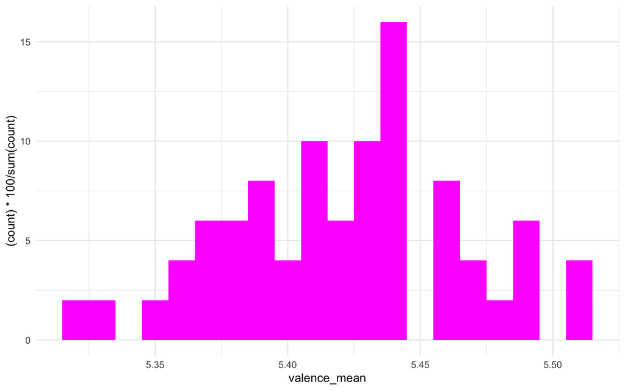

```r
# Visualize word valence with scatterplot
ggplot(data = narrative_joined, aes(x = valence_mean, y = (..count..) * 100/sum(..count..))) +
    geom_histogram(binwidth = 0.01, fill = "magenta") + theme_minimal()
```

Next, I will visualize the relation between purpose and word valence with a scatterplot:

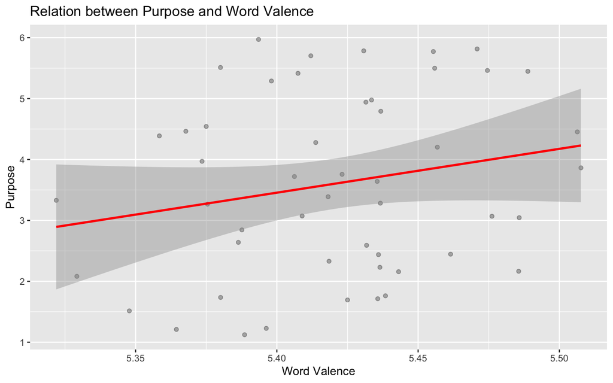

```r
# Visualize word valence by purpose with scatterplot
ggplot(narrative_joined, aes(x = valence_mean, y = purpose)) + geom_point(alpha = 0.3) +
    geom_smooth(method = "lm", color = "red") + labs(x = "Word Valence", y = "Purpose",
    title = "Relation between Purpose and Word Valence")
```

Finally, I will run my regression. First, I will load age as a covariate:

```r
purpose_valence_l1 <- lm(valence_mean ~ age, data = narrative_joined)
summary(purpose_valence_l1)
```

```
##
## Call:
## lm(formula = valence_mean ~ age, data = narrative_joined)
##
## Residuals:
##       Min        1Q    Median        3Q       Max
## -0.101376 -0.032975  0.000486  0.023483  0.084337
##
## Coefficients:
##               Estimate Std. Error t value Pr(>|t|)
## (Intercept)  5.4403948  0.0435136  125.03   <2e-16 ***
## age         -0.0002552  0.0005435   -0.47    0.641
## ---
## Signif. codes:  0 '***' 0.001 '**' 0.01 '*' 0.05 '.' 0.1 ' ' 1
##
## Residual standard error: 0.04402 on 48 degrees of freedom
## Multiple R-squared:  0.004572,   Adjusted R-squared:  -0.01617
## F-statistic: 0.2205 on 1 and 48 DF,  p-value: 0.6408
```

```r
# Age is not a significant predictor of word valence.
```

Next, I will add my purpose predictor variable:

```r
purpose_valence_l2 <- lm(valence_mean ~ age + purpose, data = narrative_joined)
summary(purpose_valence_l2)
```

```
##
## Call:
## lm(formula = valence_mean ~ age + purpose, data = narrative_joined)
##
## Residuals:
##       Min        1Q    Median        3Q       Max
## -0.101859 -0.024793 -0.003524  0.032567  0.080061
##
## Coefficients:
##               Estimate Std. Error t value Pr(>|t|)
## (Intercept)  5.4303842  0.0431759 125.773   <2e-16 ***
## age         -0.0004519  0.0005470  -0.826    0.413
## purpose      0.0071099  0.0043013   1.653    0.105
## ---
## Signif. codes:  0 '***' 0.001 '**' 0.01 '*' 0.05 '.' 0.1 ' ' 1
##
## Residual standard error: 0.04324 on 47 degrees of freedom
## Multiple R-squared:  0.05926,    Adjusted R-squared:  0.01923
## F-statistic:  1.48 on 2 and 47 DF,  p-value: 0.238
```

Takeaway 1: Purpose does NOT significantly predict word valence for  
autobiographical narratives.

## Analysis 2: Purpose Predicting Word Boredom

For my second analysis, I will run a hierarchical linear regression with  
purpose predicting word boredom for autiobiographical narratives.  
Again, I will first control for age in my model.  
Hypothesis: Higher purpose will be associated with less “bored” narratives.

First, I will visualize my variables individually:

```r
# Visualize age with scatterplot
ggplot(data = narrative_joined, aes(x = age, y = (..count..) * 100/sum(..count..))) +
    geom_histogram(binwidth = 5, fill = "magenta") + theme_minimal()
```

[output not shown]

```r
# Visualize purpose with scatterplot
ggplot(data = narrative_joined, aes(x = purpose, y = (..count..) * 100/sum(..count..))) +
    geom_histogram(binwidth = 0.5, fill = "magenta") + theme_minimal()
```

[output not shown]

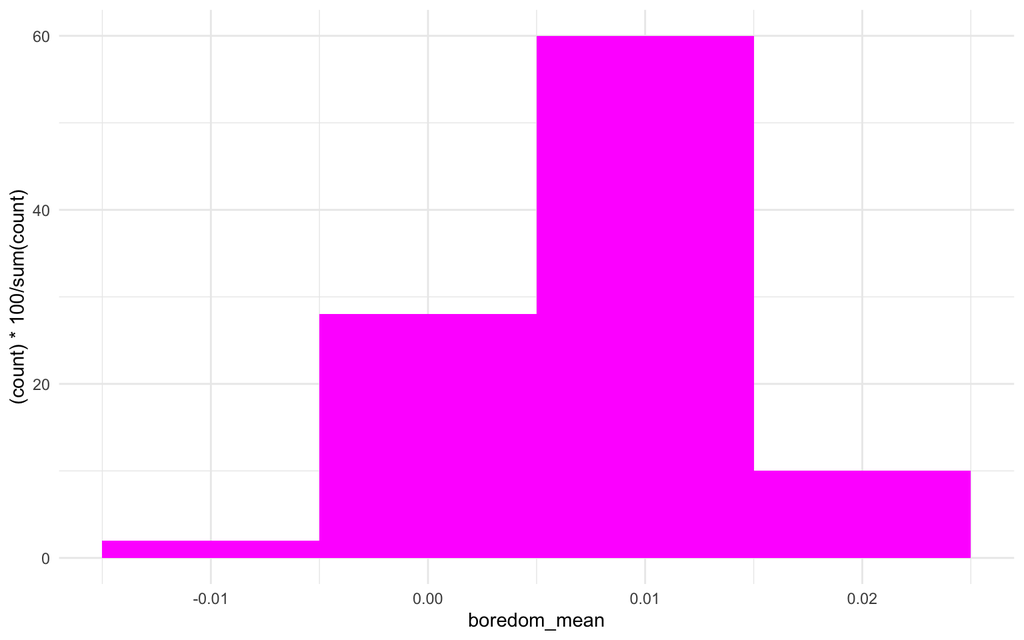

```r
# Visualize word valence with scatterplot
ggplot(data = narrative_joined, aes(x = boredom_mean, y = (..count..) * 100/sum(..count..))) +
    geom_histogram(binwidth = 0.01, fill = "magenta") + theme_minimal()
```

Next, I will visualize the relation between purpose and word boredom with a scatterplot:

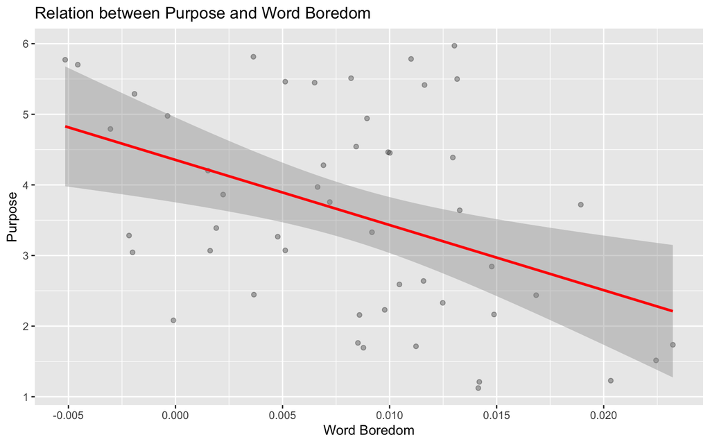

```r
# Visualize word boredom by purpose with scatterplot
ggplot(narrative_joined, aes(x = boredom_mean, y = purpose)) + geom_point(alpha = 0.3) +
    geom_smooth(method = "lm", color = "red") + labs(x = "Word Boredom", y = "Purpose",
    title = "Relation between Purpose and Word Boredom")
```

Finally, I will run my regression. First, I will load age as a covariate:

```r
purpose_boredom_l1 <- lm(boredom_mean ~ age, data = narrative_joined)
summary(purpose_boredom_l1)
```

```
##
## Call:
## lm(formula = boredom_mean ~ age, data = narrative_joined)
##
## Residuals:
##        Min         1Q     Median         3Q        Max
## -0.0130777 -0.0048743  0.0004886  0.0042792  0.0151717
##
## Coefficients:
##              Estimate Std. Error t value Pr(>|t|)
## (Intercept) 4.480e-03  6.766e-03   0.662    0.511
## age         4.656e-05  8.451e-05   0.551    0.584
##
## Residual standard error: 0.006844 on 48 degrees of freedom
## Multiple R-squared:  0.006283,   Adjusted R-squared:  -0.01442
## F-statistic: 0.3035 on 1 and 48 DF,  p-value: 0.5843
```

```r
# Age is not a significant predictor of word boredom.
```

Next, I will add my purpose predictor variable:

```r
purpose_boredom_l2 <- lm(boredom_mean ~ age + purpose, data = narrative_joined)
summary(purpose_boredom_l2)
```

```
##
## Call:
## lm(formula = boredom_mean ~ age + purpose, data = narrative_joined)
##
## Residuals:
##        Min         1Q     Median         3Q        Max
## -0.0108136 -0.0049726  0.0003337  0.0050466  0.0118335
##
## Coefficients:
##               Estimate Std. Error t value Pr(>|t|)
## (Intercept)  7.505e-03  6.148e-03   1.221    0.228
## age          1.060e-04  7.789e-05   1.361    0.180
## purpose     -2.149e-03  6.125e-04  -3.509    0.001 **
## ---
## Signif. codes:  0 '***' 0.001 '**' 0.01 '*' 0.05 '.' 0.1 ' ' 1
##
## Residual standard error: 0.006157 on 47 degrees of freedom
## Multiple R-squared:  0.2125, Adjusted R-squared:  0.179
## F-statistic: 6.342 on 2 and 47 DF,  p-value: 0.003643
```

Takeaway 2: Purpose significantly predicts word boredom of autobiographical  
narratives after controlling for age. Higher purpose is associated with  
“less bored” autobiographical narratives.

## Analysis 3: Purpose Predicting Word Excitement

For my final analysis, I will run a hierarchical linear regression with  
purpose predicting word excitement for autiobiographical narratives.  
Again, I will first control for age in my model.  
Hypothesis: Higher purpose will be associated with more “excited” narratives.

First, I will visualize my variables individually:

```r
# Visualize age with scatterplot
ggplot(data = narrative_joined, aes(x = age, y = (..count..) * 100/sum(..count..))) +
    geom_histogram(binwidth = 5, fill = "magenta") + theme_minimal()
```

[output not shown]

```r
# Visualize purpose with scatterplot
ggplot(data = narrative_joined, aes(x = purpose, y = (..count..) * 100/sum(..count..))) +
    geom_histogram(binwidth = 0.5, fill = "magenta") + theme_minimal()
```

[output not shown]

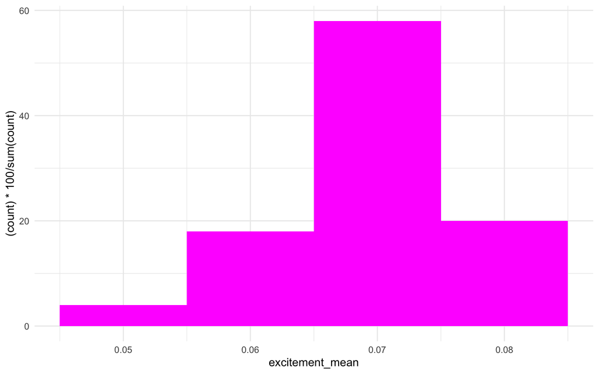

```r
# Visualize word valence with scatterplot
ggplot(data = narrative_joined, aes(x = excitement_mean, y = (..count..) * 100/sum(..count..))) +
    geom_histogram(binwidth = 0.01, fill = "magenta") + theme_minimal()
```

Next, I will visualize the relation between purpose and word excitement with a scatterplot:

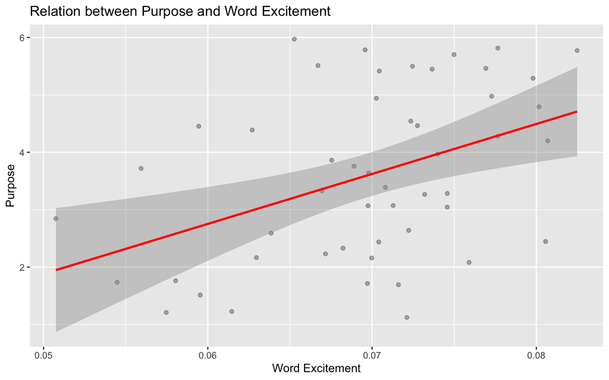

```r
# Visualize word excitement by purpose with scatterplot
ggplot(narrative_joined, aes(x = excitement_mean, y = purpose)) + geom_point(alpha = 0.3) +
    geom_smooth(method = "lm", color = "red") + labs(x = "Word Excitement", y = "Purpose",
    title = "Relation between Purpose and Word Excitement")
```

Finally, I will run my regression. First, I will load age as a covariate::

```r
purpose_excitement_l1 <- lm(excitement_mean ~ age, data = narrative_joined)
summary(purpose_excitement_l1)
```

```
##
## Call:
## lm(formula = excitement_mean ~ age, data = narrative_joined)
##
## Residuals:
##       Min        1Q    Median        3Q       Max
## -0.018500 -0.003409  0.001309  0.004763  0.012992
##
## Coefficients:
##              Estimate Std. Error t value Pr(>|t|)
## (Intercept) 6.597e-02  7.221e-03   9.135  4.5e-12 ***
## age         4.765e-05  9.020e-05   0.528      0.6
## ---
## Signif. codes:  0 '***' 0.001 '**' 0.01 '*' 0.05 '.' 0.1 ' ' 1
##
## Residual standard error: 0.007305 on 48 degrees of freedom
## Multiple R-squared:  0.005781,   Adjusted R-squared:  -0.01493
## F-statistic: 0.2791 on 1 and 48 DF,  p-value: 0.5997
```

```r
# Age is not a significant predictor of word excitement.
```

Next, I will add my purpose predictor variable:

```r
purpose_excitement_l2 <- lm(excitement_mean ~ age + purpose, data = narrative_joined)
summary(purpose_excitement_l2)
```

```
##
## Call:
## lm(formula = excitement_mean ~ age + purpose, data = narrative_joined)
##
## Residuals:
##        Min         1Q     Median         3Q        Max
## -0.0174916 -0.0035440  0.0008395  0.0045500  0.0134064
##
## Coefficients:
##               Estimate Std. Error t value Pr(>|t|)
## (Intercept)  6.296e-02  6.676e-03   9.431 2.05e-12 ***
## age         -1.137e-05  8.459e-05  -0.134  0.89364
## purpose      2.133e-03  6.651e-04   3.207  0.00241 **
## ---
## Signif. codes:  0 '***' 0.001 '**' 0.01 '*' 0.05 '.' 0.1 ' ' 1
##
## Residual standard error: 0.006687 on 47 degrees of freedom
## Multiple R-squared:  0.1843, Adjusted R-squared:  0.1496
## F-statistic: 5.309 on 2 and 47 DF,  p-value: 0.008338
```

Takeaway 3: Purpose significantly predicts word exciement of autobiographical  
narratives after controlling for age. Higher purpose is associated with  
“more excited” autobiographical narratives.

# Final Takeaways

In this simulated example, word boredom and word excitement were significantly  
influenced by purpose in life (after controlling for age), while word valence  
was not. As mentioned, these data are simulated and thus results are not real.  
That said, these analyses demonstrate a proof-of-concept for future analyses  
with real language data from my anticipated sample of older adults.